# Who are Bay Wheels' Customers?

We have seen that customers take longer rides from subscribers. Because most customers are tourists and will travel longer distances to the see the city.

What was abnormal was the distribution for the year of 2020, where it seemed that customers were more active than subscribers. Which might be due to the Covid-19 in the past couple months.

```python
baywheels = pd.read_csv('BayWheelsEdited.csv')
```

## **Subscriber / Customer:**

- Percentage of subscriber users is almost %88.15.
- Percentage of customers user is almost %11.85.

## **Average Trip Time:**

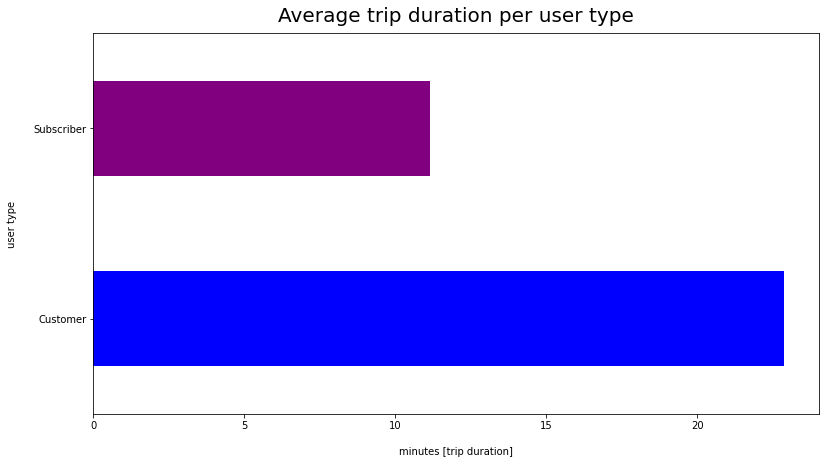

```python
new_color=['blue', 'purple']
ax = baywheels.groupby('user_type')['duration_min'].mean().plot(kind='barh', color=new_color, figsize=(13,7))
ax.set_title('Average trip duration per user type', fontsize=20, y=1.015)
ax.set_ylabel('user type', labelpad=16)
ax.set_xlabel('minutes [trip duration]', labelpad=16);
```

## **Average distance per user group**

- For customer: 1.6 miles
- For subscriber: 1.1 miles

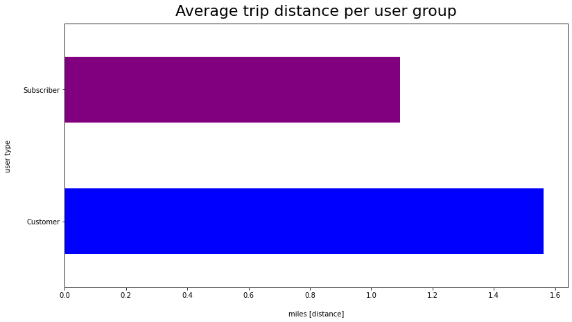

```python
ax = baywheels.groupby('user_type')['distance_miles_estimates'].mean().plot(kind='barh', color=new_color, figsize=(13,7))
ax.set_title('Average trip distance per user group', fontsize=22, y=1.015)
ax.set_ylabel('user type', labelpad=16)
ax.set_xlabel('miles [distance]', labelpad=16)
```

# What are The Usage Statistics

## **Most Used Hours**

- In weekdays: 8 AM and 5 PM
- In weekends: 12-2 PM

## **Most Used Days (Weekly Analysis)**

- For Customers: Thursday and Friday Evenings
- For Subscribers: Tuesday Mornings

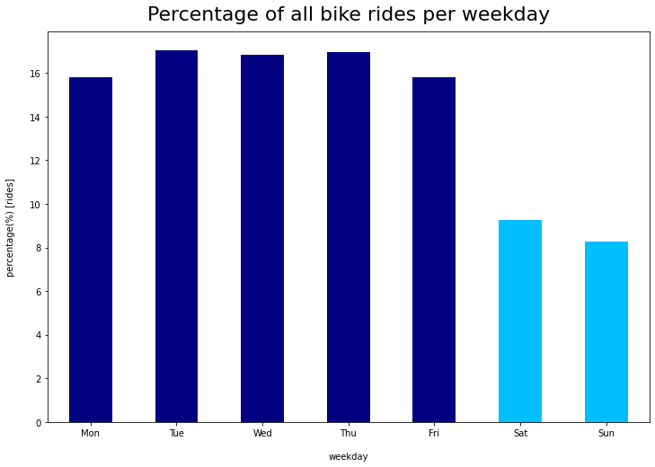

```python
new_color = ['navy', 'navy', 'navy', 'navy', 'navy', 'deepskyblue', 'deepskyblue']
trip_by_weekday_df.reindex(weekday_index)['perc'].plot(kind='bar', color=new_color, figsize=(12,8), legend=False)
plt.title('Percentage of all bike rides per weekday', fontsize=22, y=1.015)
plt.xlabel('weekday', labelpad=16)
plt.ylabel('percentage(%) [rides]', labelpad=16)
plt.xticks(rotation=360)
plt.savefig('BikeRidesPerWeekday.png');
```

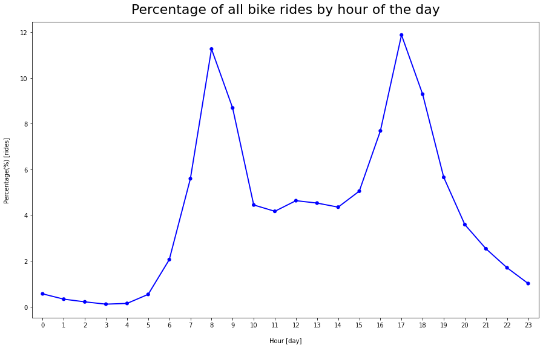

```python
trip_by_hour_baywheels = baywheels.groupby('start_time_hour').agg({'bike_id':'count'}).reset_index()
trip_by_hour_baywheels['bike_id'] = (trip_by_hour_baywheels['bike_id']/trip_by_hour_baywheels['bike_id'].sum())*100
plt.figure(figsize=(15,9))
sns.pointplot(x='start_time_hour', y='bike_id', scale=.7, color='blue', data=trip_by_hour_baywheels)
plt.title('Percentage of all bike rides by hour of the day', fontsize=22, y=1.015)
plt.xlabel('Hour [day]', labelpad=16)
plt.ylabel('Percentage(%) [rides]', labelpad=16)
plt.savefig('PeakHoursOfTheDay.png');
```

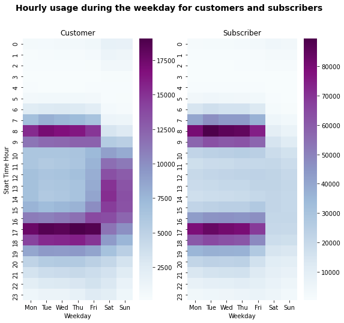

```python
# Setting the weekday order
baywheels_copy['start_time_weekday_abbr'] = pd.Categorical(baywheels_copy['start_time_weekday_abbr'],
                                                 categories=['Mon','Tue','Wed','Thu','Fri','Sat', 'Sun'],
                                                 ordered=True)
plt.figure(figsize=(9,8))
plt.suptitle('Hourly usage during the weekday for customers and subscribers', fontsize=14, fontweight='semibold')

# heatmap for customers
plt.subplot(1, 2, 1)
baywheels_customer = baywheels_copy.query('user_type == "Customer"').groupby(["start_time_hour", "start_time_weekday_abbr"])["bike_id"].size().reset_index()
baywheels_customer = baywheels_customer.pivot("start_time_hour", "start_time_weekday_abbr", "bike_id")
sns.heatmap(baywheels_customer, cmap="BuPu")

plt.title("Customer", y=1.015)
plt.xlabel('Weekday')
plt.ylabel('Start Time Hour')

# heatmap for subscribers
plt.subplot(1, 2, 2)
baywheels_subscriber = baywheels_copy.query('user_type == "Subscriber"').groupby(["start_time_hour", "start_time_weekday_abbr"])["bike_id"].size().reset_index()
baywheels_subscriber = baywheels_subscriber.pivot("start_time_hour", "start_time_weekday_abbr", "bike_id")
sns.heatmap(baywheels_subscriber, cmap="BuPu")

plt.title("Subscriber", y=1.015)
plt.xlabel('Weekday')
plt.ylabel('');
```

# What are the Most Popular Locations?

## **Where People usually Start Their trip**

- Market St at 10th St
- San Francisco Caltrain (Townsend St at 4th St)
- Berry St at 4th St
- San Francisco Ferry Building (Harry Bridges Plaza)
- San Francisco Caltrain Station 2 (Townsend St at 4th St)

## **Where People usually End Their trip**

- San Francisco Caltrain (Townsend St at 4th St)
- San Francisco Caltrain Station 2 (Townsend St at 4th St)
- San Francisco Ferry Building (Harry Bridges Plaza)
- Montgomery St BART Station (Market St at 2nd St)
- Market St at 10th St